# Methods

The MRI data used for nine of the subjects in this project comes from a different project which involved a total of 20 experimental runs divided over 3 scanning sessions. The first session included a T1-weighted anatomical scan and the second session a functional face localising run. Thereafter identical retinotopy and localiser scans were collected in a single session on further four subjects. Below we omit the details of the unused runs collected in the original project.

## Stimulus presentation

The stimuli were presented with PsychoPy v3.2.4 on an NNL LCD Monitor (32-inch, 1920 x 1080 pixels, 698.40 x 392.85 mm, refresh rate = 60 Hz) situated at the end of the scanner bore. Subjects viewed the stimuli via a mirror attached to the head-coil, at a viewing distance of 175cm.

## Retinotopic stimuli and procedure

All functional runs included a 12 second baseline at the beginning and end. The retinotopic mapping stimuli were high contrast checkerboard patterns on a gray background presented on a screen at the back of the bore and viewed by means of a mirror on the headcoil. Stimuli subtended a radius of 6.4° of visual angle from fixation and reversed contrast polarity at a temporal frequency of ~4Hz. In all functional runs, subjects were instructed to fixate at a small red central cross at all times. The subjects’ task was to indicate with a button press when the cross rotated by 45°). To further aid in fixation, the grey background included a ‘spider-web’ pattern.

In the first run (lasting 280 secs) there was a simultaneous presentation of a smoothly counter-clockwise rotating wedge (45° width, 6 rotation cycles at a frequency of 42.67 secs) and a ring that expanded outward (the outer radius was 1.5 times the inner radius, 5 expansion cycles at a frequency of 51.333 secs). The size of checkerboards for this run logarithmically increased with eccentricity.

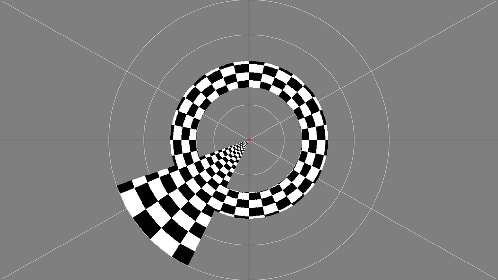

In the next two runs, (each lasting 344 secs) we presented 16 smoothly sweeping bar stimuli (1.6° wide, sweep frequency of 20 secs) which swept from one side of the screen to the other along eight equally spaced radial axes (once in one direction, once in the other). The size of the checkerboards in these runs was uniform (~0.53°).

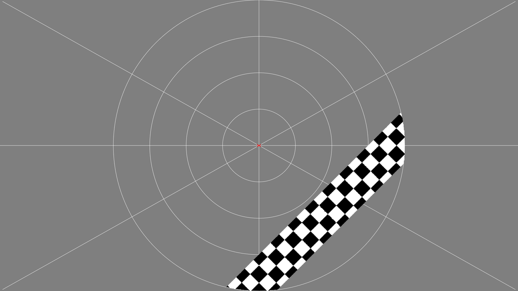

## MRI acquisition

Subjects were scanned in a 3Tesla GE Signa Premier MRI scanner with a 48ch head coil, based at Cliniques Universitaires UCL Saint-Luc in Brussels. As anatomical references, whole-brain T1-weighted images were obtained during the first sessions (3D MP-RAGE, 1 x 1 x 1 mm, FOV = 256 mm, TI = 900ms, FA = 8°). Functional T2*-weighted GE echo-planar imaging was used to obtain the blood oxygen level-dependent (BOLD) signal as an indirect measurement of neural activity. Thirty-two 2.4-mm axial slices were acquired (2.4mm isotropic, FOV = 240mm, TR = 2000ms, TE = 30ms, FA = 90°).

## Preprocessing

Functional and anatomical data were organised into the Brain Imaging Data Structure (K. J. Gorgolewski et al., 2016). Pre-processing of the data was carried out with fMRIPrep 20.1.1 (Esteban et al., 2018; Esteban et al., 2019), which is based on Nipype 1.5.0 (K. Gorgolewski et al., 2011; K. J. Gorgolewski, Nichols, Kennedy, Poline, & Poldrack, 2018). To ensure reproducibility using the specific software versions for fMRIPrep and all its dependencies, it was executed via its Docker container (Merkel, 2014).

### Anatomical data pre-processing

Each T1-weighted (T1w) volume was corrected for intensity non-uniformity (Tustison et al., 2010; N4BiasFieldCorrection), and skull-stripping was executed (antsBrainExtraction.shv, OASIS30ANTs template). Next, brain tissue segmentation of cerebrospinal fluid (CSF), white-matter (WM) and grey-matter (GM) was performed on the brain-extracted T1w (using fast from FSL 5.0.9; Zhang, Brady, & Smith, 2001). Finally, brain surfaces were reconstructed (using recon-all from FreeSurfer 6.0.1; Dale, Fischl, & Sereno, 1999), and the brain mask estimated previously was refined with a custom variation of the method to reconcile ANTs-derived and FreeSurfer-derived segmentations of the cortical grey-matter of Mindboggle (Klein et al., 2017).

### Functional data pre-processing

For each of the functional runs per subject (across all tasks and sessions), the following pre-processing was performed. First, to generate a functional reference, volumes with substantial T1w contrast derived from nonsteady states of the scanner (volumes at the beginning of EPI sequence) were identified, realigned, and averaged. After skull-stripping of the functional reference volume, head motion parameters with respect to the functional reference (transformation matrices, and six corresponding rotation and translation parameters) were estimated (Jenkinson, Bannister, Brady, & Smith, 2002; mcflirt - FSL 5.0.9). On average, the maximum movement was 1.38 ± 0.21 mm.

After correcting for slice timing (Cox & Hyde, 1997; 3dTshift from AFNI 20160207), the functional reference was co-registered to the T1w reference using boundary-based registration (bbregister, FreeSurfer; Greve & Fischl, 2009). Since the volumes were within the same subject, co-registration was configured with six degrees of freedom (i.e. 3 rotations and 3 translations).

Next, all functional data were resampled onto their original, native space by applying the transforms to correct for head-motion. Several confounding time series were calculated based on the functional data: framewise displacement (FD), DVARS and three region-wise global signals. FD was computed with the absolute sum of relative motions (Power, Power et al., 2014) and the relative root mean square displacement between affines (Jenkinson, Jenkinson et al., 2002). FD and DVARS were calculated for each functional run, both using their implementations in Nipype (Power et al., 2014). Frames that exceeded a threshold of 0.5 mm FD or 1.5 standardised DVARS were annotated as motion outliers. The three global signals were extracted within the CSF, the WM, and the whole-brain masks.

Using FEAT (FMRI Expert Analysis Tool; Version 6.0; FMRIB’s Software Library, www.fmrib.ox.ac.uk/fsl) the functional data were smoothed in the space domain using a Gaussian kernel of FWHM 5mm. And high-pass temporal filtering was carried out using a Gaussian-weighted least-squares straight-line fitting (sigma=50.0s).

## Measurement of pRFs

Before fitting, the data were spatially smoothed using matlab’s `smooth3` function with a gaussian kernal size of 3x3x3 voxels. For each voxel, the mean of each run was removed and the data concatenated in the time dimension before being detrended using matlab’s `detrend` function with an 8th degree polynomial. For every voxel in the posterior lobe, we computed the correlation between the observed timecourse and each of the predicted timecourse. The winning model was simply the one with the highest correlation. While more sophisticated parameter selection methods exist, we are confident that any overfitting would not impact on the large-scale organisation of the retinotopic maps produced from these model fits. Indeed, we observed a high level of agreement between the borders of V1/V2 as suggested by the functional maps and the V1/V2 border of the *Freesurfer* atlas labels fitted based on surface curvature.

## References

Dumoulin, S. O., & Wandell, B. A. (2008). Population receptive field estimates in human visual cortex. Neuroimage, 39(2), 647-660.

Cox, R.W. (1996). AFNI: software for analysis and visualization of functional magnetic resonance neuroimages. Comput Biomed Res 29(3):162-173. doi:10.1006/cbmr.1996.0014

Schwarzkopf, D.S., Song, C., Rees, G. (2011). The surface area of human V1 predicts the subjective experience of object size. Nature Neuroscience 14(1):28-30. doi: 10.1038/nn.2706. Epub 2010 Dec 5.